# Lecture Notes · Complex Numbers · Session 1 — The complex numbers and their plane

> The rigorous construction (ordered pairs, no mysticism), the properties of the conjugate and the modulus proved, the formula for the inverse, the Argand plane, and the complete proof that ℂ admits no compatible order. Exercises and a Going further section at the end.

## 1.1 The construction

**Definition 2.1.1.** A **complex number** is an ordered pair $(a,b) \in \mathbb{R} \times \mathbb{R}$ (Cartesian product, M0). On the set $\mathbb{C}$ of such pairs one defines:
$$(a,b) + (c,d) = (a+c,\; b+d), \qquad (a,b)\cdot(c,d) = (ac - bd,\; ad + bc).$$

**Proposition 2.1.2.** 1. Pairs of the form $(a, 0)$ operate among themselves exactly like the reals: $(a,0)+(c,0) = (a+c, 0)$ and $(a,0)(c,0) = (ac, 0)$. We identify $a \leftrightarrow (a,0)$: **$\mathbb{R}$ lives inside $\mathbb{C}$**, respecting the operations. 2. Writing $i = (0,1)$: $\;i^2 = (0,1)(0,1) = (0\cdot 0 - 1 \cdot 1,\; 0\cdot 1 + 1 \cdot 0) = (-1, 0) = -1$. 3. Every pair can be written in a **unique way** as $(a,b) = a + bi$ (the **rectangular form**), and the operations of 1.1 are those of “operating with distributivity and substituting $i^2 = -1$”.

*Proof.* (1) and (2): direct computation with Definition 2.1.1. (3) $(a,b) = (a,0) + (0,b) = (a,0) + (b,0)(0,1) = a + bi$; uniqueness is that of the components of the pair. That the operations agree: expanding $(a+bi)(c+di)$ with distributivity and $i^2 = -1$ gives $(ac - bd) + (ad + bc)i$ — the formula of 1.1. $\blacksquare$

> **The point of the approach:** $i$ is not a mysterious entity one “has to take on faith”: it is the pair $(0,1)$, and $i^2 = -1$ is a **computation** (Proposition 2.1.2(2)). The product formula is not arbitrary: it is the only one compatible with distributivity and with $i^2 = -1$ (that is what Proposition 2.1.2(3) says). The ring properties (associativity, commutativity, distributivity, identities $0 = (0,0)$ and $1 = (1,0)$) can be checked mechanically from 1.1 — exercise 6 does one; the rest are identical.

## 1.2 Conjugate and modulus

**Definition 2.1.3.** For $z = a + bi$: the **conjugate** $\bar z = a - bi$; the **modulus** $|z| = \sqrt{a^2 + b^2}$; the **real part** $\mathrm{Re} z = a$ and the **imaginary part** $\mathrm{Im} z = b$ — *careful: $\mathrm{Im} z$ is the real number $b$, **not** $bi$; this is the most frequent error of the topic*. One says that $z$ is **purely imaginary** when $\mathrm{Re} z = 0$, that is, when $z = bi$ with $b \in \mathbb{R}$: these are exactly the points of the vertical axis.

**Proposition 2.1.4 (properties of the conjugate).** 1. $\overline{z + w} = \bar z + \bar w$ and $\overline{z \cdot w} = \bar z \cdot \bar w$ (conjugation respects the operations). 2. $\bar{\bar z} = z$; $\;z + \bar z = 2\mathrm{Re} z$; $\;z - \bar z = 2i \mathrm{Im} z$. 3. $z = \bar z \iff z \in \mathbb{R}$.

*Proof.* (1, the product — the least obvious one): with $z = a+bi$, $w = c+di$: $\overline{zw} = (ac-bd) - (ad+bc)i$, and $\bar z \bar w = (a-bi)(c-di) = (ac - bd) + (-ad - bc)i$ — they coincide. (Sum: immediate.) (2) and (3): read off directly from the definitions. $\blacksquare$

**Proposition 2.1.5 (the key identity).** $\;z \cdot \bar z = |z|^2$ — a **real** number, $\ge 0$, and zero only if $z = 0$.

*Proof.* $(a+bi)(a-bi) = a^2 - (bi)^2 = a^2 + b^2$. It is a sum of real squares: $\ge 0$, and $= 0$ only when $a = b = 0$. $\blacksquare$

**Theorem 2.1.6 (division: $\mathbb{C}$ is a field).** Every $z \neq 0$ has an inverse:
$$z^{-1} = \frac{\bar z}{|z|^2}.$$

*Proof.* $z \cdot \dfrac{\bar z}{|z|^2} = \dfrac{z \bar z}{|z|^2} = \dfrac{|z|^2}{|z|^2} = 1$ (legitimate: $|z|^2 \neq 0$ by 2.1.5). $\blacksquare$

> **The fields thread, second stop:** $\mathbb{Z}/p\mathbb{Z}$ (Arithmetic, finite) and now $\mathbb{C}$ — two worlds where every nonzero element is invertible. The name **field** is used as a label; the formal definition and its theory arrive in Linear Algebra. **In practice:** to divide, multiply numerator and denominator by the conjugate of the denominator — and Proposition 2.1.5 is the reason why (it makes the denominator real).

**Corollary 2.1.7.** $|z w| = |z| |w|$.

*Proof.* $|zw|^2 = (zw)\overline{(zw)} = z \bar z\, w \bar w = |z|^2 |w|^2$ (using Proposition 2.1.4(1) and commutativity); take square roots of nonnegatives. $\blacksquare$

## 1.3 The Argand plane

Definition 2.1.1 already **is** the identification: $a + bi$ is the point $(a,b)$ of the plane. Horizontal axis = the reals; vertical axis = the purely imaginary numbers.

- **Addition = parallelogram:** componentwise.
- **Modulus = distance to the origin** (school Pythagoras; $|z - w|$ = distance between the points — the general theory of distances, in the Geometry module).
- **Conjugation = reflection** across the real axis.
- The **product** has a spectacular geometric reading — Session 2.

[figure not shown]

Argand plane: the point $z=a+bi$ in coordinates $(a,b)$; the sum $z+w$ as the fourth vertex of the parallelogram of $z$ and $w$.

[figure not shown]

Conjugation as reflection across the real axis: $z=a+bi$ and $\bar z=a-bi$ are symmetric, with $|z|=|\bar z|$.

## 1.4 $\mathbb{C}$ cannot be ordered (the price of the construction)

**Proposition 2.1.8.** There is no **total** order on $\mathbb{C}$ compatible with the operations, that is, an order satisfying **(T)** given $a, b$, either $a < b$, or $a = b$, or $b < a$; **(O1)** $a < b \Rightarrow a + c < b + c$; and **(O2)** $0 < a,\, 0 < b \Rightarrow 0 < ab$.

*Proof (by contradiction, M0).* Suppose one exists. *Step 1: every square of a nonzero element is positive.* By (T), an $x \neq 0$ falls into one of two cases. If $x > 0$, then $x \cdot x > 0$ by (O2). If $x < 0$, adding $-x$ to both sides by (O1): $0 < -x$, so $(-x)(-x) > 0$ by (O2), and $(-x)(-x) = x^2$. In particular $1 = 1^2 > 0$, and adding $-1$ by (O1): $-1 < 0$. *Step 2:* $i \neq 0$, so $i^2 > 0$ by Step 1 — but $i^2 = -1 < 0$. Contradiction. $\blacksquare$

> Much is gained (all equations, S3) and something real is lost: in $\mathbb{C}$, “$z < w$” makes no sense. This lack will reappear: **metric** geometry (the Geometry module) needs an ordered field, and that is why it lives in $\mathbb{R}$ and not in $\mathbb{C}$.

## Exercises

1. ★ Compute $(2+3i)(1-2i)$, $\;\dfrac{3+4i}{1-2i}$ and $\dfrac{1}{i}$ — the divisions **via the conjugate**, indicating in each one where Proposition 2.1.5 acts.
2. ★ Plot in the plane: $z = 2 + i$, $\bar z$, $-z$, $iz$ and $z + (1 - 2i)$ (the last one with its parallelogram). What does each operation do to $z$ geometrically?
3. ★ Solve $z^2 - 4z + 13 = 0$ and check both solutions. Notice: they are conjugates — coincidence? (This will come back in S3.)
4. Prove properties 2.1.4(2) and 2.1.4(3) from the definitions.
5. Prove: $|\bar z| = |z|$, and $|z| = 0 \iff z = 0$.
6. Verify the **associativity of the product** from Definition 2.1.1 for three generic pairs (mechanical but instructive: the rigor of the construction exacts this price only once).
7. Prove that $\mathrm{Re}(z) \le |z|$ and $|z + w| \le |z| + |w|$. *(Hint for the second: $|z+w|^2 = (z+w)(\bar z + \bar w)$, expand and use the first with $z\bar w$.)*
8. **(Structural counterfactual, guided.)** Reproduce the proof of Proposition 2.1.8 filling in every step, and point out exactly which axiom of the order — (T), (O1) or (O2) — is used in each line.

## Going further and references

> **Going further (the true history).** The complex numbers were not born from $x^2 + 1 = 0$ (that equation was dismissed with “no solution”) but from the **cubics**: Cardano’s formula (16th century), applied to cubics with three real roots, forced one to pass through square roots of negative numbers *in intermediate steps* — Bombelli discovered that, computing with them formally, the correct real results emerged. Complex numbers entered mathematics **because they worked**, two centuries before Hamilton gave (in 1835) the construction by pairs of Definition 2.1.1. See Needham, *Visual Complex Analysis*, ch. 1.

> **References.** Construction and operations: Hernández, *Álgebra y geometría*; Childs. The geometric view (all of this module’s): Needham, ch. 1 — the star reference.

# Lecture Notes · Complex Numbers · Session 2 — Polar form: multiplying is rotating

> The product theorem in polar form with its proof, the complete geometric reading, De Moivre proved by induction (including the case of negative exponents), and the exponential notation with its status honestly discussed. Exercises and a Going further section at the end.

## 2.1 The polar form

**Definition 2.2.1.** For $z = a + bi \neq 0$: its **modulus** is $r = |z|$ and an **argument** is any angle $\theta$ with
$$a = r\cos\theta, \qquad b = r\sin\theta, \qquad \text{that is,} \qquad z = r(\cos\theta + i \sin\theta).$$

[figure not shown]

Polar form: the modulus $r=|z|$ is the distance to the origin and the argument $\theta$ the angle with the real axis; $a=r\cos\theta$, $b=r\sin\theta$.

**Proposition 2.2.2 (the argument, up to full turns).** Every $z \neq 0$ has an argument, and two arguments of $z$ differ by an **integer multiple of $2\pi$**. The representative in $(-\pi, \pi]$ is called the **principal argument**.

*Proof.* Existence: the point $(a/r,\, b/r)$ lies on the unit circle, and every point on it is $(\cos\theta, \sin\theta)$ for some $\theta$ (trigonometry). If $\theta, \theta'$ are arguments of the same $z$: $\cos\theta = \cos\theta'$ and $\sin\theta = \sin\theta'$ holding simultaneously force $\theta - \theta' \in 2\pi\mathbb{Z}$. $\blacksquare$

[figure not shown]

The argument is defined up to multiples of $2\pi$: $\theta$, $\theta+2\pi$, $\theta-2\pi$ point to the same point. The representative in $(-\pi,\pi]$ is the principal argument.

> **This “up to $2\pi$” is not fine print:** it is exactly the mechanism that in Session 3 will make the $n$ $n$-th roots sprout. It deserves to be treated with respect from now on.

**Method 2.2.3 (translation, with the quadrants watched).** From polar to rectangular there is no mystery: $a = r\cos\theta$, $b = r\sin\theta$. The care is needed in the reverse direction.

*From rectangular to polar.* The modulus is direct, $r = \sqrt{a^2+b^2}$. The argument comes from $\tan\theta = b/a$, **but $\arctan$ is not enough**: the function $\arctan$ always returns an angle in $(-\tfrac{\pi}{2}, \tfrac{\pi}{2})$, that is, **it can only see quadrants I and IV** (those with $a>0$). If the point lies to the left of the imaginary axis ($a<0$), $\arctan(b/a)$ points to the **diametrically opposite** complex number — the one with argument $\theta\pm\pi$ — because $\tan$ does not distinguish an angle from its opposite through the origin. One must correct according to the signs of $(a,b)$. Taking the principal argument in $(-\pi,\pi]$:

| Sign of $(a,b)$ | Quadrant / axis | Principal argument $\theta$ |
| --- | --- | --- |
| $a>0$ (any $b$) | I and IV | $\arctan(b/a)$ |
| $a<0,\ b\ge 0$ | II | $\arctan(b/a) + \pi$ |
| $a<0,\ b<0$ | III | $\arctan(b/a) - \pi$ |
| $a=0,\ b>0$ | $+i$ axis | $+\pi/2$ |
| $a=0,\ b<0$ | $-i$ axis | $-\pi/2$ |

*(The $\pm\pi$ criterion in the $a<0$ rows is just “choose the sign that lands inside $(-\pi,\pi]$”: add $\pi$ if $b\ge 0$, subtract it if $b<0$. It is what the `atan2(b, a)` function of calculators and programming languages automates.)*

*Examples of the classic mistake.* (i) $z = -1 - i$: $\tan\theta = 1$, but it lies in the **third** quadrant, so $\theta = \arctan(1) - \pi = \tfrac{\pi}{4} - \pi = -\tfrac{3\pi}{4}$ — **not** $\pi/4$, which would be $1+i$. (ii) $z = -1 + i$: same $|\tan\theta|$, second quadrant: $\theta = \arctan(-1) + \pi = -\tfrac{\pi}{4} + \pi = \tfrac{3\pi}{4}$. Both share $\tan\theta=\pm1$ with points in the first/fourth quadrant; the picture always disambiguates: **look at which quadrant $(a,b)$ falls in before fixing the angle.**

[figure not shown]

$\arctan(b/a)$ gives the correct argument only if $a\gt 0$ (quadrants I and IV); in II and III one must add or subtract $\pi$ (here $z=-1+i$).

## 2.2 The theorem: multiplying is rotating

**Theorem 2.2.4 (product in polar form).** If $z_1 = r_1(\cos\alpha + i\sin\alpha)$ and $z_2 = r_2(\cos\beta + i\sin\beta)$:
$$z_1 z_2 = r_1 r_2\big(\cos(\alpha + \beta) + i \sin(\alpha+\beta)\big).$$
**Moduli multiply and arguments add.**

*Proof.* Multiplying in rectangular form:
$$z_1 z_2 = r_1 r_2\big[(\cos\alpha\cos\beta - \sin\alpha\sin\beta) + i(\cos\alpha\sin\beta + \sin\alpha\cos\beta)\big],$$
and the two parentheses are, exactly, the **angle addition** formulas: $\cos(\alpha+\beta)$ and $\sin(\alpha+\beta)$. $\blacksquare$

**Geometric reading (the jewel).** Multiplying by $z = r e^{i\theta}$ transforms the plane by **rotating** it through an angle $\theta$ and **scaling** it by $r$. Cases that illuminate it:

- Multiplying by $i$ (modulus 1, argument $\pi/2$): a **90° rotation**. And then $i^2 = -1$ stops being an oddity: **two 90° rotations are a half turn**, and a half turn is multiplying by $-1$. The “impossible” equation of S1 was plain geometry all along. *(With the status made clear: this is **not a new proof** of $i^2 = -1$. The reading “multiplying by $i$ is rotating by 90°” was deduced from Theorem 2.2.4, which was proved by multiplying in rectangular form — where $i^2 = -1$ was already inside. It is the same truth, seen at last in a form one can remember.)*
- By a positive real: it only scales. By $-1$: half turn. By $\bar z / |z|^2$ (the inverse, Theorem 2.1.6): rotate by $-\theta$ and scale by $1/r$ — **undoing**.

[figure not shown]

Multiplying by $z^{-1}$ undoes what $z$ does: if $z$ rotates by $\theta$ and scales by $r$, then $z^{-1}$ rotates by $-\theta$ and scales by $1/r$, taking $zw$ back to $w$.

[interactive chart not shown]

Multiplying by a fixed complex number $z=r\,e^{i\theta}$ transforms $w$ into $zw$ by rotating through an angle $\theta$ and scaling by $r$; cases $z=i$ (90°), $z=-1$ (half turn), $z=z^{-1}$ (undo).

**The conjugate in polar form, explicitly.** Conjugating meant flipping the sign of the imaginary part; in polar form it is **replacing the angle by its opposite**, and it is enough to write it out using $\cos(-\theta) = \cos\theta$ and $\sin(-\theta) = -\sin\theta$:
$$\bar z = r\big(\cos(-\theta) + i\,\sin(-\theta)\big) = r(\cos\theta - i\,\sin\theta), \qquad \text{that is}\qquad \overline{r e^{i\theta}} = r e^{-i\theta}.$$
Same modulus, opposite argument: the mirror across the real axis from S1, now as a formula. And dividing by $|z|^2 = r^2$ the inverse drops out with no new computation:
$$z^{-1} = \frac{\bar z}{|z|^2} = \frac{1}{r}(\cos\theta - i\,\sin\theta) = \frac{1}{r}e^{-i\theta}.$$

> **That $-\theta$ is *an* argument, not yet *the* principal one.** $\arg(z^{-1}) = -\theta$ holds **up to $2\pi$** (Proposition 2.2.2), and the representative the convention asks for lives in $(-\pi, \pi]$. When $\theta = \pi$ — that is, $z$ a negative real — the candidate $-\theta = -\pi$ **falls outside the interval on its open end**, and one must add $2\pi$: the principal argument of the inverse is again $\boxed{\pi}$, not $-\pi$. And so it must be, because the inverse of a negative real is a negative real: $(-r)^{-1} = -1/r$, still on the $\pi$ half-axis. It is the only angle in the interval without a symmetric partner, precisely because it is the endpoint that *is* included.

> *A mention pointing forward:* “rotating and scaling the plane” is the prototype of the transformations that the Linear Algebra module will study in general; this example will be waiting for you there.

## 2.3 De Moivre

**Theorem 2.2.5 (De Moivre).** For every $n \in \mathbb{Z}$ and $z = r(\cos\theta + i\sin\theta) \neq 0$:
$$z^n = r^n\big(\cos(n\theta) + i\sin(n\theta)\big).$$

*Proof.* **$n \ge 1$, by induction (M0):** the case $n = 1$ is the definition; the step $n \to n+1$ is Theorem 2.2.4 applied to $z^n \cdot z$ (moduli $r^n \cdot r$, arguments $n\theta + \theta$). **$n = 0$:** both sides equal $1$. **$n < 0$:** writing $n = -m$ with $m > 0$, $z^{-m} = (z^m)^{-1}$, and the inverse inverts the modulus and changes the sign of the argument (geometric reading of Theorem 2.1.6, checked in exercise 5): modulus $r^{-m}$, argument $-m\theta$. $\blacksquare$

**Example 2.2.6.** $(1+i)^{10}$: in polar form, $1 + i = \sqrt{2}\, e^{i\pi/4}$; De Moivre: $(\sqrt 2)^{10} e^{i\,10\pi/4} = 32\, e^{i 5\pi/2} = 32\, e^{i\pi/2} = 32 i$. (Reducing the argument modulo $2\pi$ — the convention again.) No binomial theorem, no suffering.

## 2.4 The exponential notation (and its status, honestly)

**Definition-notation 2.2.7 (Euler’s formula).** One writes
$$e^{i\theta} := \cos\theta + i\sin\theta,$$
so that every $z \neq 0$ is $z = r e^{i\theta}$, and Theorem 2.2.4 becomes the **rule of exponents**: $e^{i\alpha} e^{i\beta} = e^{i(\alpha+\beta)}$, and De Moivre becomes $(e^{i\theta})^n = e^{in\theta}$.

**Euler’s identity, which costs nothing here.** Evaluating notation 2.2.7 at $\theta = \pi$: $e^{i\pi} = \cos\pi + i\,\sin\pi = -1$, that is
$$e^{i\pi} + 1 = 0.$$
Five fundamental constants in one line. It is worth seeing **why it is trivial here**: nothing has been proved, a definition has been evaluated at $\theta = \pi$. All the substance sits in the notation deserving the exponential symbol, which is what the next box discusses.

> **The status, no tricks:** at this level, $e^{i\theta}$ is a **notation** — extraordinarily convenient, and *deserving* of the exponential symbol precisely because it obeys the rule of exponents. That rule, however, **is not a gift of the notation**: it is Theorem 2.2.4 rewritten, just as $(e^{i\theta})^n = e^{in\theta}$ is Theorem 2.2.5 rewritten. The notation makes them evident; it does not prove them. The deep justification (that the exponential series, evaluated at $i\theta$, gives cosine and sine) belongs to analysis and to another course: **we use the notation; we do not pretend to have proved the identity of the series.** For those who want a peek: Going further.

## Exercises

1. ★ Convert to polar form (quadrant watched): $1 + i$, $\;-1 + i$, $\;-2$, $\;-1 - \sqrt{3}\,i$. And to rectangular form: $2e^{i\pi/3}$, $\;e^{-i\pi/2}$.
2. ★ Compute with De Moivre and reduce the argument: $(1 - i)^8$, $\;(\sqrt 3 + i)^6$. Check the first by expanding $(1-i)^2$ by hand and raising.
3. ★ Describe geometrically (rotation + scaling, with the picture) the transformation “multiply by”: (a) $2i$; (b) $\frac{1+i}{\sqrt 2}$; (c) $-3$.
4. ★ Deduce from De Moivre with $n = 2$ the **double angle** identities ($\cos 2\theta = \cos^2\theta - \sin^2\theta$, $\sin 2\theta = 2\sin\theta\cos\theta$) by equating real and imaginary parts. Repeat with $n = 3$ for the triple angle.
5. Check that $z^{-1} = \bar z/|z|^2$ has modulus $1/r$ and argument $-\theta$ (the geometric reading used in Theorem 2.2.5, and asserted in video S2 V2).
6. Prove $|zw| = |z||w|$ with Theorem 2.2.4, and compare it with the proof via conjugates from S1 (Corollary 2.1.7): two proofs, one identity — what does each contribute?
7. For which $z$ is $z^2 = \bar z$? Solve it **in polar form** (moduli and arguments separately) and draw the solutions.

## Going further and references

> **Going further (when Euler’s identity is a theorem).** Above, $e^{i\pi} + 1 = 0$ comes from substituting into a definition, which is why it is free. The identity — repeatedly voted “the most beautiful formula” — earns the name **theorem** when $e^{z}$ is defined by its series and one proves that, evaluated at $i\theta$, it reproduces cosine and sine: then the equality connects two independent definitions instead of unfolding a single one. That is analysis and another course. The full bridge: Needham, ch. 1, or any complex analysis text.

> **References.** Polar form and De Moivre: Hernández; Childs. The “multiplying is rotating” view as a guiding thread: Needham, *Visual Complex Analysis*, ch. 1 (highly recommended reading for this session).

# Lecture Notes · Complex Numbers · Session 3 — n-th roots and the fundamental theorem of algebra

> The n-roots theorem with its complete proof (existence and exactness of the count), the geometry of the polygon, the roots of unity with their multiplicative structure and the vanishing sum proved, the worked example in full, the conjugate symmetry of the roots of real polynomials (proved with what is already at hand), and the FTA with its honest status. Exercises and a Going further section at the end.

## 3.1 The n-th roots

**Theorem 2.3.1.** Let $w = R\,e^{i\varphi} \neq 0$ and $n \ge 1$. The equation $z^n = w$ has **exactly $n$ complex solutions**:
$$z_k = R^{1/n} \, e^{i\theta_k}, \qquad \theta_k = \frac{\varphi + 2k\pi}{n}, \qquad k = 0, 1, \dots, n-1,$$
where $R^{1/n}$ is the **positive real** $n$-th root of $R$.

*Proof.* We look for $z = r e^{i\theta}$ with $r > 0$. By De Moivre, $z^n = r^n e^{in\theta}$, and the equation $z^n = w$ is equivalent to the pair of conditions:

- **Moduli:** $r^n = R$. Since $r$ is a positive real, $r = R^{1/n}$, and it is **unique** (the function $r \mapsto r^n$ is strictly increasing on the positive reals — a school fact).
- **Arguments:** $n\theta$ must be an argument of $w$, and the arguments of $w$ are $\varphi + 2k\pi$ with $k \in \mathbb{Z}$ (Proposition 2.2.2 — *here the “up to $2\pi$” comes alive*). Hence $\theta = (\varphi + 2k\pi)/n$ for some $k \in \mathbb{Z}$.

*Exact count.* For $k = 0, \dots, n-1$, the angles $\theta_k$ are pairwise distinct **modulo $2\pi$** (two of them differ by $\frac{2\pi(k - k')}{n}$ with $0 < |k - k'| < n$, which is not a multiple of $2\pi$), so they give $n$ distinct complex numbers. And for any other $k \in \mathbb{Z}$, writing $k = qn + k'$ with $0 \le k' < n$ (Euclidean division, Arithmetic S1!): $\theta_k = \theta_{k'} + 2q\pi$ — the same complex number. Exactly $n$. $\blacksquare$

**The geometry.** The $n$ roots share the modulus $R^{1/n}$ and their arguments advance in constant steps of $2\pi/n$: they are the **vertices of a regular polygon with $n$ sides** centered at the origin. Operationally: compute **one** root and the rest come out by **rotating** it through $2\pi/n$ each time.

[figure not shown]

The $n$ solutions of $z^n=w$ on the circle of radius $R^{1/n}$: a starting root at the angle $\varphi/n$ and the rest obtained by rotating it in steps of $2\pi/n$, forming a regular polygon with $n$ sides.

[interactive chart not shown]

n-th roots of unity with a slider on $n$: as $n$ varies, the number of vertices of the regular polygon inscribed in the unit circle changes.

### A worked example in full

**Example 2.3.1.1.** $z^3 = -8$. In polar form: $-8 = 8\,e^{i\pi}$. Modulus: $8^{1/3} = 2$. Arguments: $\theta_k = \frac{\pi + 2k\pi}{3}$:
$$z_0 = 2e^{i\pi/3} = 1 + \sqrt 3\, i, \qquad z_1 = 2e^{i\pi} = -2, \qquad z_2 = 2e^{i 5\pi/3} = 1 - \sqrt 3\, i.$$
*Checks:* $(-2)^3 = -8$ ✓; and $z_0^3 = 8 e^{i\pi} = -8$ ✓ (De Moivre). Observe: $z_2 = \bar{z_0}$ — not by chance (§3.3).

[figure not shown]

Solutions of $z^3=-8$: an equilateral triangle of radius $2$ with one vertex at $-2$ and the others at $1\pm\sqrt3\,i$, symmetric with respect to the real axis ($z_2=\bar{z_0}$).

## 3.2 The roots of unity

**Definition 2.3.2.** The **$n$-th roots of unity** are the solutions of $z^n = 1$: by Theorem 2.3.1 (with $R = 1, \varphi = 0$),
$$\omega_k = e^{2k\pi i/n}, \qquad k = 0, 1, \dots, n-1$$
— the regular polygon with $n$ vertices inscribed in the unit circle, with one vertex at $1$.

**Proposition 2.3.3 (multiplicative structure).** Writing $\omega = \omega_1 = e^{2\pi i/n}$: all the roots are **powers of the first one**, $\omega_k = \omega^k$, and the product of two roots of unity is another one: $\omega_j \omega_k = \omega_{j+k \bmod n}$ — the vertices of the polygon **multiply among themselves** according to the sum of indices modulo $n$ (the arithmetic of $\mathbb{Z}/n\mathbb{Z}$, reappearing in geometry!).

*Proof.* $\omega^k = e^{2k\pi i/n}$ by De Moivre; and $\omega_j \omega_k = e^{2(j+k)\pi i/n}$, where $j + k$ can be reduced modulo $n$ by adjusting by $2\pi$ (Proposition 2.2.2). $\blacksquare$

[figure not shown]

Roots of unity for $n=3$ (triangle), $n=4$ (square) and $n=6$ (hexagon): the $\omega_k=e^{2k\pi i/n}$ as vertices of the polygon inscribed in the unit circle, with $\omega_0=1$.

> **Remark 2.3.3.1 (the roots-of-unity “dictionary” is an isomorphism).** The correspondence
> $$\mathbb{Z}/n\mathbb{Z} \longrightarrow \{n\text{-th roots of unity}\}, \qquad k \bmod n \longmapsto \omega^k,$$
> is **well defined** (if $k \equiv k' \pmod n$ then $\omega^k = \omega^{k'}$, because $\omega^n = 1$: the root depends only on the remainder, not on the representative), is a **bijection** (the $\omega^k$ with $0 \le k < n$ are distinct and are all the roots) and **respects the operation**: the sum of indices modulo $n$ translates into the product of roots, $\omega^{j} \omega^{k} = \omega^{j+k \bmod n}$ (Proposition 2.3.3). A bijection that carries one operation into another is called an **isomorphism**: the additive arithmetic of $\mathbb{Z}/n\mathbb{Z}$ and the multiplicative arithmetic of the roots of unity are, structurally, **the same**. *(Note: taking another primitive root instead of $\omega$ gives another equally valid dictionary; which ones are primitive is made precise in the Going further section. The term “isomorphism” and its theory arrive in Algebra; here the operative definition suffices: a bijection that respects the operation.)*

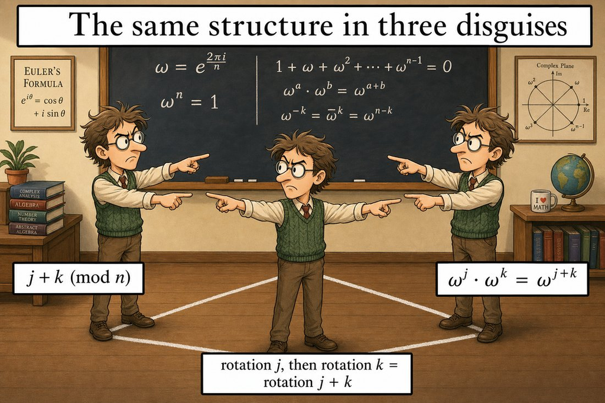

Remark 2.3.3.1 in pocket form: residues modulo $n$, roots of unity and rotations of the polygon are **the same computation in three disguises** — the dictionary transports the operation, not just the names.

**Proposition 2.3.4 (the vanishing sum).** For $n \ge 2$: $\;\omega_0 + \omega_1 + \cdots + \omega_{n-1} = 0$.

*Proof.* Let $S$ be the sum. Multiplying by $\omega$ ($\neq 1$ since $n \ge 2$): $\omega S = \omega_1 + \omega_2 + \cdots + \omega_{n-1} + \omega_n$, and $\omega_n = \omega_0$ — the same list, rearranged: $\omega S = S$. Then $(\omega - 1)S = 0$, and since $\omega \neq 1$ and $\mathbb{C}$ is a field (Theorem 2.1.6: every nonzero element has an inverse) it has no zero divisors, so $S = 0$. *(Geometrically: the center of mass of the polygon is the origin.)* $\blacksquare$

## 3.3 Roots of real polynomials come in pairs

**Proposition 2.3.6.** Let $p(z) = c_n z^n + \cdots + c_1 z + c_0$ have **real** coefficients. If $z_0$ is a root, so is $\bar{z_0}$.

*Proof.* Conjugation respects sums and products (Proposition 2.1.4(1)) and fixes the reals (Proposition 2.1.4(3)), so
$$p(\bar{z_0}) = c_n \bar{z_0}^{\,n} + \cdots + c_0 = \overline{c_n z_0^n + \cdots + c_0} = \overline{p(z_0)} = \bar 0 = 0. \;\blacksquare$$

> *(That is why the solutions of exercise 3 in S1 came out conjugate, and why $z_2 = \bar{z_0}$ in Example 2.3.1.1: $z^3 + 8$ has real coefficients.)* **Announced consequence:** the non-real roots of a real polynomial group into pairs; combined with the FTA and factorization (the Polynomials module), this will give that *every real polynomial of odd degree has a real root*. The fine count is completed there.

## 3.4 The fundamental theorem of algebra

**Theorem 2.3.7 (FTA — statement).** Every nonconstant polynomial with coefficients in $\mathbb{C}$ has at least one root in $\mathbb{C}$.

**What it means.** We built $\mathbb{C}$ (S1) to solve *one* equation; the FTA says that **everything** got solved: no polynomial equation forces any further extension.

**Definition 2.3.8 (algebraically closed).** A field $K$ is *algebraically closed* if every nonconstant polynomial in $K[x]$ has a root in $K$. In these terms, Theorem 2.3.7 says exactly that $\mathbb{C}$ is algebraically closed. *(Factoring repeatedly, it follows that over $\mathbb{C}$ every polynomial of degree $n$ has exactly $n$ roots counted with multiplicity; the fine count is completed in the Polynomials module.)*

**What it does not say.** It gives no method to *find* the root — it only guarantees that it exists. Our effective methods remain the usual ones: quadratics, $n$-th roots, and whatever the Polynomials module contributes.

> **Honesty about the proof.** It is not proved in this course, and it is worth saying why: despite the name, **every proof of the FTA uses analysis at some point** (the completeness of $\mathbb{R}$ — that $\mathbb{R}$ “is not missing any points”); pure algebra is not enough. In the Polynomials module we will **use** it as a factorization tool, citing it. For the curious reader, the Going further section sketches the idea of a proof.

## Exercises

1. ★ Compute and **draw** all the roots of: $z^4 = 16$, $\;z^3 = i$, $\;z^6 = 1$. (The polygon is part of the answer.)
2. ★ Solve $z^2 + 2z + 5 = 0$ and $z^4 + z^2 - 2 = 0$ (substitution $u = z^2$; some root of $u$ will be negative — now we know what to do with it). Check Proposition 2.3.6 in both.
3. ★ Check by De Moivre that $z_0 = 1 + \sqrt 3\, i$ from Example 2.3.1.1 satisfies $z_0^3 = -8$, and that the three roots found are the only ones (which part of Theorem 2.3.1 guarantees this?).
4. ★ In the hexagon of the sixth roots of unity, mark which ones are also cube roots, which are square roots, and verify $\omega_2 \cdot \omega_5 = \omega_1$ (Proposition 2.3.3) on the picture.
5. Prove that the product of the $n$ roots of unity is $(-1)^{n+1}$. *(Hint: $\omega_0 \omega_1 \cdots \omega_{n-1} = \omega^{0+1+\cdots+(n-1)}$ and the Gauss sum.)*
6. How many **real** roots does $z^n = 1$ have, depending on the parity of $n$? Answer it from the picture of the polygon and from the formula.
7. A real polynomial of degree 3 has $2 - i$ as a root. What are the other possibilities for its roots? Can it have no real root? (Use Proposition 2.3.6; the formal closure of the argument will arrive in Polynomials.)
8. **(GeoGebra.)** Construct the $n$-th roots of a draggable $w$ with a slider on $n$; observe what happens to the polygon when $w$ rotates and when $|w|$ grows.

## Going further and references

> **Going further (the idea of a proof of the FTA).** The most visual one: for huge $|z|$, $p(z) \approx c_n z^n$, so the image of a large circle “winds $n$ times” around the origin; for $|z| = 0$ the image is the point $p(0)$. As the circle shrinks from large to small, those turns have to come undone — and they cannot come undone without **crossing the origin**: there lies a root. Making “winding” and “crossing” rigorous is exactly the analytic-topological part that exceeds this course. Needham, ch. 7, tells it splendidly.

> **Going further (roots of unity in the real world — Data profile).** The $\omega_k$ are the basis of the **discrete Fourier transform** and of the **FFT** algorithm that computes it fast — signal processing, audio and image compression, fast multiplication of enormous numbers. The structure “the vertices multiply like $\mathbb{Z}/n\mathbb{Z}$” (Proposition 2.3.3) has a technical name — *cyclic group* — and a theory of its own: Childs, or Aluffi, ch. II.

> **References.** Roots and polygons: Hernández; Needham, ch. 1. FTA: statement and context in Childs; the visual proof in Needham, ch. 7.